[figure not shown]

# TOEPASSING SPREIDINGSDIAGRAM - REGRESSIE

## OLD FAITHFUL GEISER - OEFENING

In deze notebook zal je een regressielijn bepalen bij de data m.b.t. de activiteit van de geiser Old Faitful. Een regressielijn is een rechte die het best past bij de data en een eventuele trend die vervat is in de data, weerspiegelt.

### Nodige modules importeren

```python
import numpy as np
import matplotlib.pyplot as plt
import pandas as pd

from scipy.optimize import curve_fit                # voor regressie
```

## 1. Data inlezen en visualiseren

De Old Faithful geiser in het Yellowstone National Park in de VS barst op regelmatige tijdstippen uit. Je leest een csv-file in die de wachttijd tussen de erupties en de duurtijd van de erupties in minuten bevat voor 272 observaties [1]. Je zal deze data visualiseren.  
Het bestand vind je in de map `data`: `oldfaithfulgeiser.csv`.

### Opgave

Lees het bestand in en laat de puntenwolk zien.

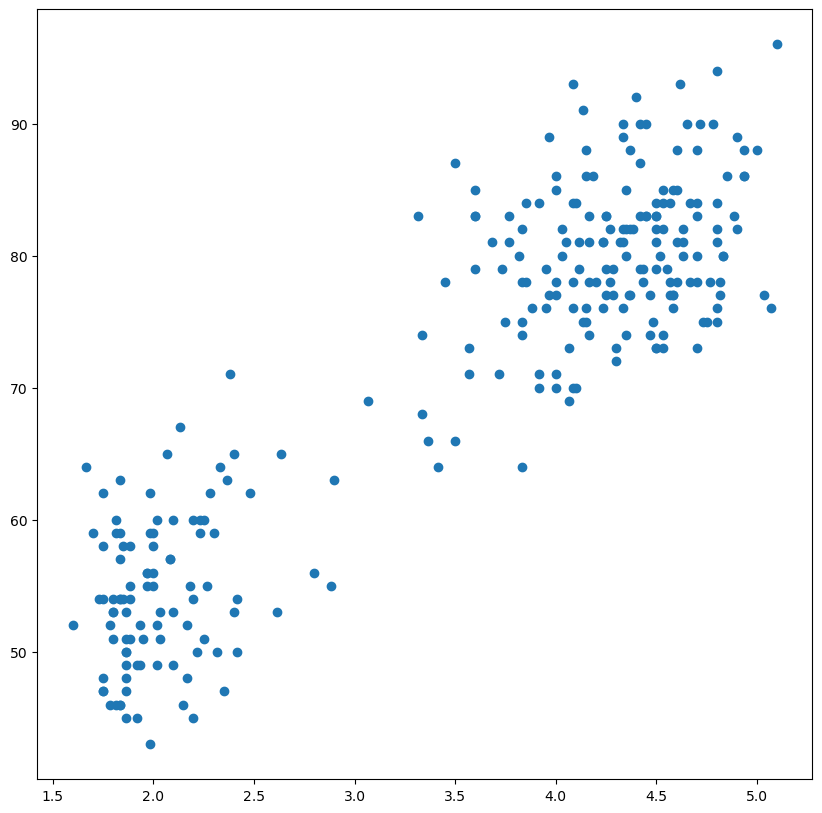

```python
csv = pd.read_csv('data/oldfaithfulgeiser.csv')

x = np.array(csv['eruptie'])
y = np.array(csv['wacht'])

plt.figure(figsize=(10, 10))

plt.scatter(x, y)

plt.show()
```

## 2. Lineaire regressie en grafische voorstelling

### Opdracht

```python
def rechte(x, a, b):
    return a * x + b

def linreg(x, y):
    popt, pcov = curve_fit(rechte, x, y)

    a, b = popt
    return a, b

a, b = linreg(x, y)
print(a, b)
```

```
10.729641379213666 33.474397084945174
```

## 3. Vergelijking van de regressielijn

### Opdracht

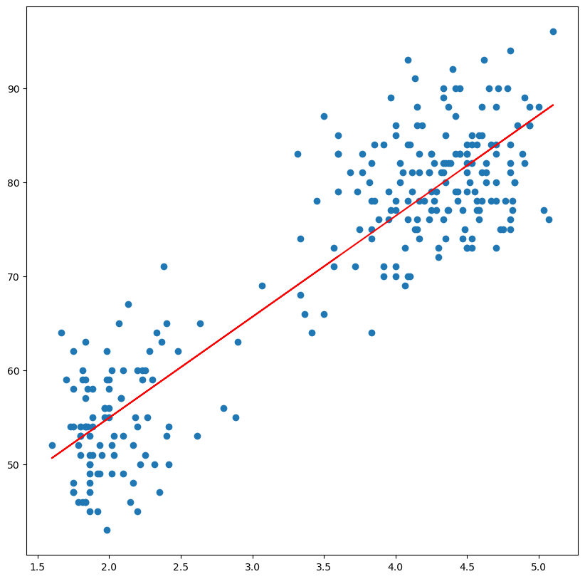

```python
plt.figure(figsize=(10, 10))

plt.plot(x, rechte(x, a, b), color="red")

plt.scatter(x, y)

plt.show()
```

### Referentielijst

[1] Wasserman, L. (2013). All of Statistics. https://www.stat.cmu.edu/~larry/all-of-statistics/

Notebook Python in wiskunde, zie Computationeel denken - Programmeren in Python van [AI Op School](http://www.aiopschool.be), van F. wyffels & N. Gesquière, in licentie gegeven volgens een [Creative Commons Naamsvermelding-NietCommercieel-GelijkDelen 4.0 Internationaal-licentie](http://creativecommons.org/licenses/by-nc-sa/4.0/).